# Lab week 1 - penalized linear models

Data Science 2: Machine Learning Concepts - CEU 2021

Janos K. Divenyi, Jeno Pal

2021-02-08

```r
library(tidyverse)
library(GGally)   # ggplot extensions
library(caret)
library(magrittr)
library(skimr)
library(janitor)  # for data cleaning purposes
library(glmnet)   # the main package for penalized linear models
library(broom)    # for tidying regression coefficient outputs
library(knitr)
library(kableExtra)  # for nicer tables in rmarkdown

theme_set(theme_bw())   # globally set ggplot theme
```

Disclaimer: this lab borrows lots of ideas and examples from [this](https://afit-r.github.io/regularized_regression) great tutorial.

## Data: Ames Housing dataset

We are going to predict house sales prices in Ames, Iowa. See [here](https://cran.r-project.org/web/packages/AmesHousing/index.html).

```r
library(AmesHousing)
housing_data <- make_ames()
housing_data <- clean_names(housing_data)
housing_data <- housing_data %>% mutate(log_sale_price = log(sale_price))
skim(housing_data)
```

Data summary

| Name | housing_data |
| --- | --- |
| Number of rows | 2930 |
| Number of columns | 82 |
| _______________________ |  |
| Column type frequency: |  |
| factor | 46 |
| numeric | 36 |
| ________________________ |  |
| Group variables | None |

**Variable type: factor**

| skim_variable | n_missing | complete_rate | ordered | n_unique | top_counts |
| --- | --- | --- | --- | --- | --- |
| ms_sub_class | 0 | 1 | FALSE | 16 | One: 1079, Two: 575, One: 287, One: 192 |
| ms_zoning | 0 | 1 | FALSE | 7 | Res: 2273, Res: 462, Flo: 139, Res: 27 |
| street | 0 | 1 | FALSE | 2 | Pav: 2918, Grv: 12 |
| alley | 0 | 1 | FALSE | 3 | No_: 2732, Gra: 120, Pav: 78 |
| lot_shape | 0 | 1 | FALSE | 4 | Reg: 1859, Sli: 979, Mod: 76, Irr: 16 |
| land_contour | 0 | 1 | FALSE | 4 | Lvl: 2633, HLS: 120, Bnk: 117, Low: 60 |
| utilities | 0 | 1 | FALSE | 3 | All: 2927, NoS: 2, NoS: 1 |
| lot_config | 0 | 1 | FALSE | 5 | Ins: 2140, Cor: 511, Cul: 180, FR2: 85 |
| land_slope | 0 | 1 | FALSE | 3 | Gtl: 2789, Mod: 125, Sev: 16 |
| neighborhood | 0 | 1 | FALSE | 28 | Nor: 443, Col: 267, Old: 239, Edw: 194 |
| condition_1 | 0 | 1 | FALSE | 9 | Nor: 2522, Fee: 164, Art: 92, RRA: 50 |
| condition_2 | 0 | 1 | FALSE | 8 | Nor: 2900, Fee: 13, Art: 5, Pos: 4 |
| bldg_type | 0 | 1 | FALSE | 5 | One: 2425, Twn: 233, Dup: 109, Twn: 101 |
| house_style | 0 | 1 | FALSE | 8 | One: 1481, Two: 873, One: 314, SLv: 128 |
| overall_qual | 0 | 1 | FALSE | 10 | Ave: 825, Abo: 732, Goo: 602, Ver: 350 |
| overall_cond | 0 | 1 | FALSE | 9 | Ave: 1654, Abo: 533, Goo: 390, Ver: 144 |
| roof_style | 0 | 1 | FALSE | 6 | Gab: 2321, Hip: 551, Gam: 22, Fla: 20 |
| roof_matl | 0 | 1 | FALSE | 8 | Com: 2887, Tar: 23, WdS: 9, WdS: 7 |
| exterior_1st | 0 | 1 | FALSE | 16 | Vin: 1026, Met: 450, HdB: 442, Wd : 420 |
| exterior_2nd | 0 | 1 | FALSE | 17 | Vin: 1015, Met: 447, HdB: 406, Wd : 397 |
| mas_vnr_type | 0 | 1 | FALSE | 5 | Non: 1775, Brk: 880, Sto: 249, Brk: 25 |
| exter_qual | 0 | 1 | FALSE | 4 | Typ: 1799, Goo: 989, Exc: 107, Fai: 35 |
| exter_cond | 0 | 1 | FALSE | 5 | Typ: 2549, Goo: 299, Fai: 67, Exc: 12 |
| foundation | 0 | 1 | FALSE | 6 | PCo: 1310, CBl: 1244, Brk: 311, Sla: 49 |
| bsmt_qual | 0 | 1 | FALSE | 6 | Typ: 1283, Goo: 1219, Exc: 258, Fai: 88 |
| bsmt_cond | 0 | 1 | FALSE | 6 | Typ: 2616, Goo: 122, Fai: 104, No_: 80 |
| bsmt_exposure | 0 | 1 | FALSE | 5 | No: 1906, Av: 418, Gd: 284, Mn: 239 |
| bsmt_fin_type_1 | 0 | 1 | FALSE | 7 | GLQ: 859, Unf: 851, ALQ: 429, Rec: 288 |
| bsmt_fin_type_2 | 0 | 1 | FALSE | 7 | Unf: 2499, Rec: 106, LwQ: 89, No_: 81 |
| heating | 0 | 1 | FALSE | 6 | Gas: 2885, Gas: 27, Gra: 9, Wal: 6 |
| heating_qc | 0 | 1 | FALSE | 5 | Exc: 1495, Typ: 864, Goo: 476, Fai: 92 |
| central_air | 0 | 1 | FALSE | 2 | Y: 2734, N: 196 |
| electrical | 0 | 1 | FALSE | 6 | SBr: 2682, Fus: 188, Fus: 50, Fus: 8 |
| kitchen_qual | 0 | 1 | FALSE | 5 | Typ: 1494, Goo: 1160, Exc: 205, Fai: 70 |
| functional | 0 | 1 | FALSE | 8 | Typ: 2728, Min: 70, Min: 65, Mod: 35 |
| fireplace_qu | 0 | 1 | FALSE | 6 | No_: 1422, Goo: 744, Typ: 600, Fai: 75 |
| garage_type | 0 | 1 | FALSE | 7 | Att: 1731, Det: 782, Bui: 186, No_: 157 |
| garage_finish | 0 | 1 | FALSE | 4 | Unf: 1231, RFn: 812, Fin: 728, No_: 159 |
| garage_qual | 0 | 1 | FALSE | 6 | Typ: 2615, No_: 159, Fai: 124, Goo: 24 |
| garage_cond | 0 | 1 | FALSE | 6 | Typ: 2665, No_: 159, Fai: 74, Goo: 15 |
| paved_drive | 0 | 1 | FALSE | 3 | Pav: 2652, Dir: 216, Par: 62 |
| pool_qc | 0 | 1 | FALSE | 5 | No_: 2917, Exc: 4, Goo: 4, Typ: 3 |
| fence | 0 | 1 | FALSE | 5 | No_: 2358, Min: 330, Goo: 118, Goo: 112 |
| misc_feature | 0 | 1 | FALSE | 6 | Non: 2824, She: 95, Gar: 5, Oth: 4 |
| sale_type | 0 | 1 | FALSE | 10 | WD : 2536, New: 239, COD: 87, Con: 26 |
| sale_condition | 0 | 1 | FALSE | 6 | Nor: 2413, Par: 245, Abn: 190, Fam: 46 |

**Variable type: numeric**

| skim_variable | n_missing | complete_rate | mean | sd | p0 | p25 | p50 | p75 | p100 | hist |
| --- | --- | --- | --- | --- | --- | --- | --- | --- | --- | --- |
| lot_frontage | 0 | 1 | 57.65 | 33.50 | 0.00 | 43.00 | 63.00 | 78.00 | 313.00 | ▇▇▁▁▁ |
| lot_area | 0 | 1 | 10147.92 | 7880.02 | 1300.00 | 7440.25 | 9436.50 | 11555.25 | 215245.00 | ▇▁▁▁▁ |
| year_built | 0 | 1 | 1971.36 | 30.25 | 1872.00 | 1954.00 | 1973.00 | 2001.00 | 2010.00 | ▁▂▃▆▇ |
| year_remod_add | 0 | 1 | 1984.27 | 20.86 | 1950.00 | 1965.00 | 1993.00 | 2004.00 | 2010.00 | ▅▂▂▃▇ |
| mas_vnr_area | 0 | 1 | 101.10 | 178.63 | 0.00 | 0.00 | 0.00 | 162.75 | 1600.00 | ▇▁▁▁▁ |
| bsmt_fin_sf_1 | 0 | 1 | 4.18 | 2.23 | 0.00 | 3.00 | 3.00 | 7.00 | 7.00 | ▃▂▇▁▇ |
| bsmt_fin_sf_2 | 0 | 1 | 49.71 | 169.14 | 0.00 | 0.00 | 0.00 | 0.00 | 1526.00 | ▇▁▁▁▁ |
| bsmt_unf_sf | 0 | 1 | 559.07 | 439.54 | 0.00 | 219.00 | 465.50 | 801.75 | 2336.00 | ▇▅▂▁▁ |
| total_bsmt_sf | 0 | 1 | 1051.26 | 440.97 | 0.00 | 793.00 | 990.00 | 1301.50 | 6110.00 | ▇▃▁▁▁ |
| first_flr_sf | 0 | 1 | 1159.56 | 391.89 | 334.00 | 876.25 | 1084.00 | 1384.00 | 5095.00 | ▇▃▁▁▁ |
| second_flr_sf | 0 | 1 | 335.46 | 428.40 | 0.00 | 0.00 | 0.00 | 703.75 | 2065.00 | ▇▃▂▁▁ |
| low_qual_fin_sf | 0 | 1 | 4.68 | 46.31 | 0.00 | 0.00 | 0.00 | 0.00 | 1064.00 | ▇▁▁▁▁ |
| gr_liv_area | 0 | 1 | 1499.69 | 505.51 | 334.00 | 1126.00 | 1442.00 | 1742.75 | 5642.00 | ▇▇▁▁▁ |
| bsmt_full_bath | 0 | 1 | 0.43 | 0.52 | 0.00 | 0.00 | 0.00 | 1.00 | 3.00 | ▇▆▁▁▁ |
| bsmt_half_bath | 0 | 1 | 0.06 | 0.25 | 0.00 | 0.00 | 0.00 | 0.00 | 2.00 | ▇▁▁▁▁ |
| full_bath | 0 | 1 | 1.57 | 0.55 | 0.00 | 1.00 | 2.00 | 2.00 | 4.00 | ▁▇▇▁▁ |
| half_bath | 0 | 1 | 0.38 | 0.50 | 0.00 | 0.00 | 0.00 | 1.00 | 2.00 | ▇▁▅▁▁ |
| bedroom_abv_gr | 0 | 1 | 2.85 | 0.83 | 0.00 | 2.00 | 3.00 | 3.00 | 8.00 | ▁▇▂▁▁ |
| kitchen_abv_gr | 0 | 1 | 1.04 | 0.21 | 0.00 | 1.00 | 1.00 | 1.00 | 3.00 | ▁▇▁▁▁ |
| tot_rms_abv_grd | 0 | 1 | 6.44 | 1.57 | 2.00 | 5.00 | 6.00 | 7.00 | 15.00 | ▁▇▂▁▁ |
| fireplaces | 0 | 1 | 0.60 | 0.65 | 0.00 | 0.00 | 1.00 | 1.00 | 4.00 | ▇▇▁▁▁ |
| garage_cars | 0 | 1 | 1.77 | 0.76 | 0.00 | 1.00 | 2.00 | 2.00 | 5.00 | ▅▇▂▁▁ |
| garage_area | 0 | 1 | 472.66 | 215.19 | 0.00 | 320.00 | 480.00 | 576.00 | 1488.00 | ▃▇▃▁▁ |
| wood_deck_sf | 0 | 1 | 93.75 | 126.36 | 0.00 | 0.00 | 0.00 | 168.00 | 1424.00 | ▇▁▁▁▁ |
| open_porch_sf | 0 | 1 | 47.53 | 67.48 | 0.00 | 0.00 | 27.00 | 70.00 | 742.00 | ▇▁▁▁▁ |
| enclosed_porch | 0 | 1 | 23.01 | 64.14 | 0.00 | 0.00 | 0.00 | 0.00 | 1012.00 | ▇▁▁▁▁ |
| three_season_porch | 0 | 1 | 2.59 | 25.14 | 0.00 | 0.00 | 0.00 | 0.00 | 508.00 | ▇▁▁▁▁ |
| screen_porch | 0 | 1 | 16.00 | 56.09 | 0.00 | 0.00 | 0.00 | 0.00 | 576.00 | ▇▁▁▁▁ |
| pool_area | 0 | 1 | 2.24 | 35.60 | 0.00 | 0.00 | 0.00 | 0.00 | 800.00 | ▇▁▁▁▁ |
| misc_val | 0 | 1 | 50.64 | 566.34 | 0.00 | 0.00 | 0.00 | 0.00 | 17000.00 | ▇▁▁▁▁ |
| mo_sold | 0 | 1 | 6.22 | 2.71 | 1.00 | 4.00 | 6.00 | 8.00 | 12.00 | ▅▆▇▃▃ |
| year_sold | 0 | 1 | 2007.79 | 1.32 | 2006.00 | 2007.00 | 2008.00 | 2009.00 | 2010.00 | ▇▇▇▇▃ |
| sale_price | 0 | 1 | 180796.06 | 79886.69 | 12789.00 | 129500.00 | 160000.00 | 213500.00 | 755000.00 | ▇▇▁▁▁ |
| longitude | 0 | 1 | -93.64 | 0.03 | -93.69 | -93.66 | -93.64 | -93.62 | -93.58 | ▅▅▇▆▁ |
| latitude | 0 | 1 | 42.03 | 0.02 | 41.99 | 42.02 | 42.03 | 42.05 | 42.06 | ▂▂▇▇▇ |
| log_sale_price | 0 | 1 | 12.02 | 0.41 | 9.46 | 11.77 | 11.98 | 12.27 | 13.53 | ▁▁▆▇▁ |

Look at the outcome variable, the price of houses.

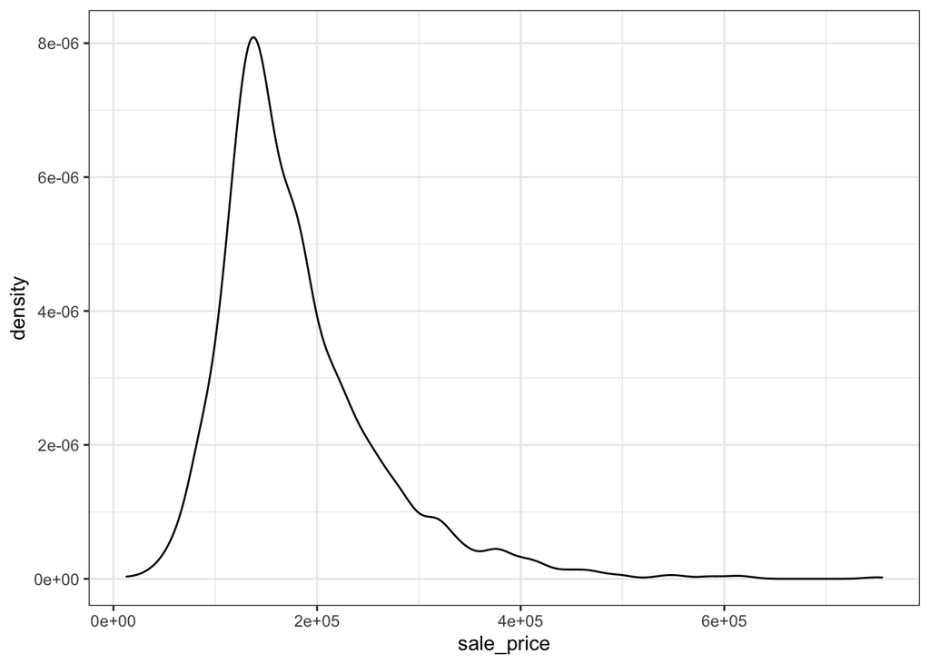

```r
ggplot(data = housing_data, aes(x = sale_price)) + geom_density()
```

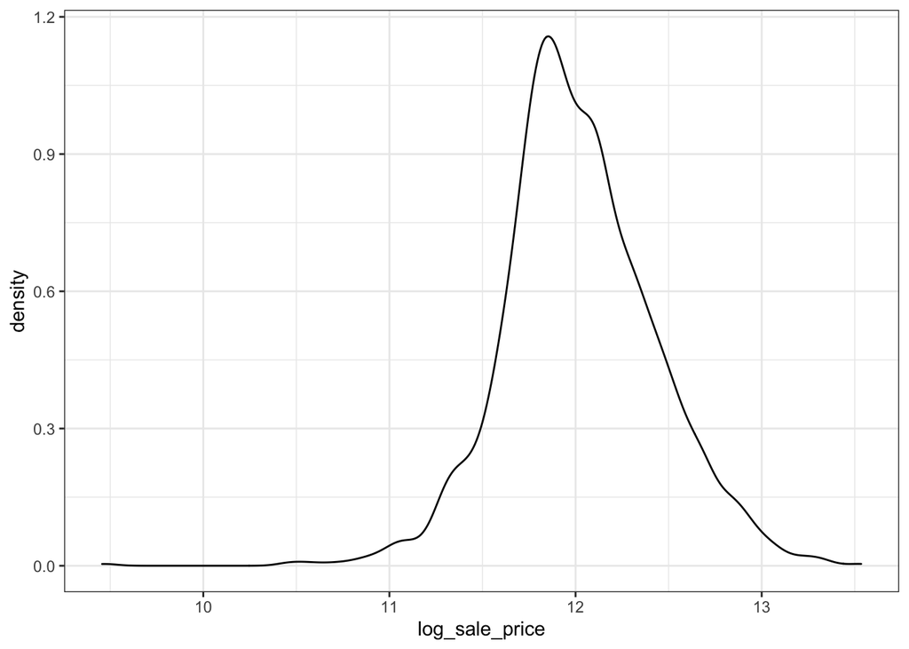

```r
ggplot(data = housing_data, aes(x = log_sale_price)) + geom_density()
```

Let’s see correlations of features and the outcome variable. Based on this, simple benchmark models can quickly be put together.

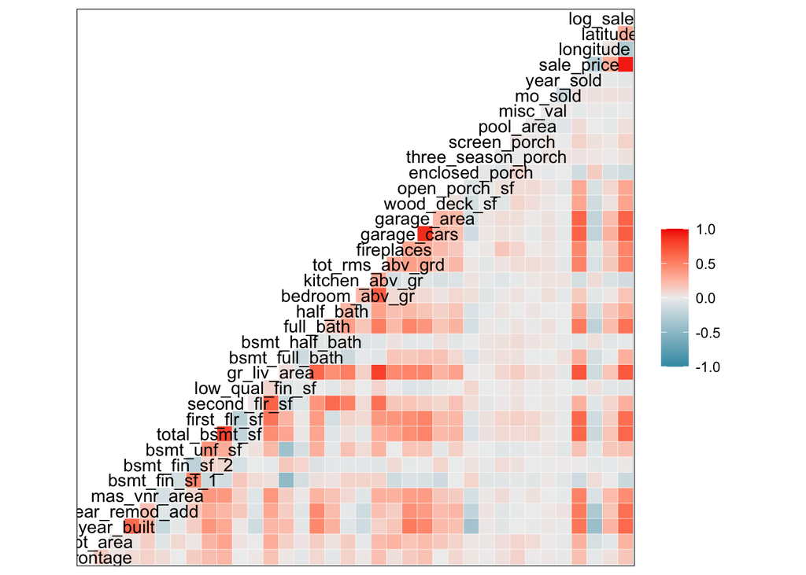

```r
ggcorr(housing_data)
```

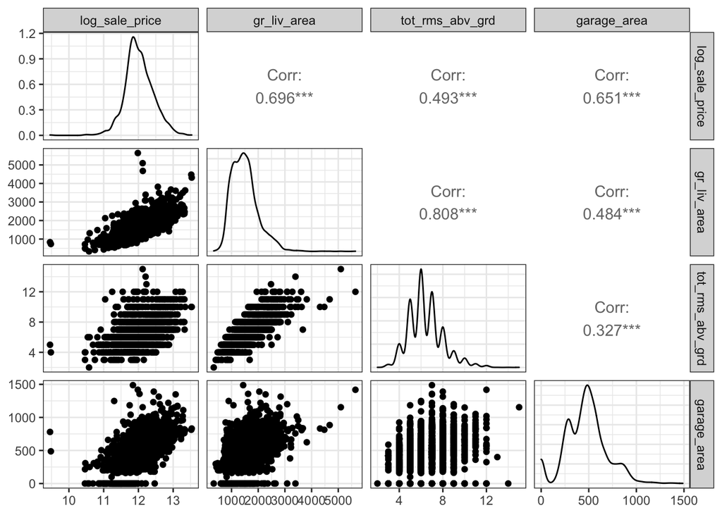

```r
ggpairs(housing_data, columns = c("log_sale_price", "gr_liv_area", "tot_rms_abv_grd", "garage_area"))
```

### A baseline model

```r
lm(log_sale_price ~ gr_liv_area + tot_rms_abv_grd, data = housing_data) %>%
  tidy() %>%
  kable(digits = 3) %>%
  kable_styling(full_width = F)
```

| term | estimate | std.error | statistic | p.value |
| --- | --- | --- | --- | --- |
| (Intercept) | 11.318 | 0.023 | 498.266 | 0 |
| gr_liv_area | 0.001 | 0.000 | 38.602 | 0 |
| tot_rms_abv_grd | -0.052 | 0.006 | -9.006 | 0 |

Weird pattern: sales price decreases with the number of rooms? This is spurious and is caused by the high positive correlation between the feature variables. Univariate regressions have the intuitive signs:

```r
lm(log_sale_price ~ gr_liv_area, data = housing_data) %>%
  tidy() %>%
  kable(digits = 3) %>%
  kable_styling(full_width = F)
```

| term | estimate | std.error | statistic | p.value |
| --- | --- | --- | --- | --- |
| (Intercept) | 11.180 | 0.017 | 660.123 | 0 |
| gr_liv_area | 0.001 | 0.000 | 52.430 | 0 |

```r
lm(log_sale_price ~ tot_rms_abv_grd, data = housing_data) %>%
  tidy() %>%
  kable(digits = 3) %>%
  kable_styling(full_width = F)
```

| term | estimate | std.error | statistic | p.value |
| --- | --- | --- | --- | --- |
| (Intercept) | 11.199 | 0.028 | 405.172 | 0 |
| tot_rms_abv_grd | 0.128 | 0.004 | 30.627 | 0 |

Penalized methods offer a solution to these kinds of patterns.

### Set up training and test (holdout) datasets

```r
set.seed(1234)
training_ratio <- 0.7
train_indices <- createDataPartition(
  y = housing_data[["log_sale_price"]],
  times = 1,
  p = training_ratio,
  list = FALSE
) %>% as.vector()
data_train <- housing_data[train_indices, ]
data_test <- housing_data[-train_indices, ]

fit_control <- trainControl(method = "cv", number = 10)
```

## Penalize large coefficients: the Ridge regression

The ridge regression adds a penalty term to the sum of squared residuals: the sum of squares of the regression coefficients. This puts a cost on having large coefficients. Result: biased but lower variance model.

```r
features <- setdiff(names(housing_data), c("sale_price", "log_sale_price"))
```

First we are going to directly work with the `glmnet` package to estimate penalized models. Then we look at how this can be implemented through `caret`.

```r
# glmnet needs inputs as a matrix. model.matrix: handles factor variables
# -1: we do not need the intercept as glment will automatically include it
x_train <- model.matrix( ~ . -1, data_train[, features, with = FALSE])
dim(x_train)
```

```
## [1] 2053  309
```

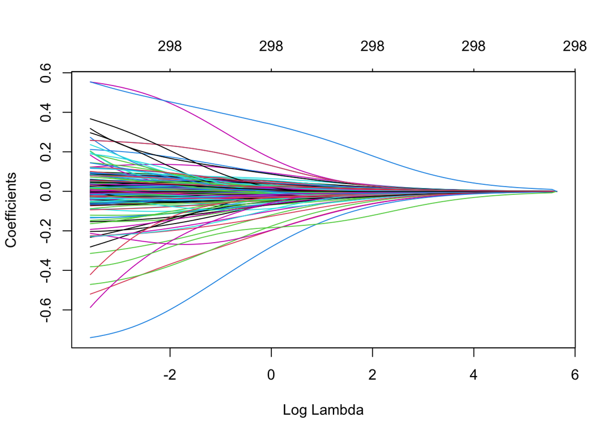

```r
# standardization of variables is automatically done by glmnet

# how much penalty do we want to apply? select with CV
lambda_grid <- 10^seq(2,-5,length=100)

set.seed(1234)
ridge_model <- glmnet(
  x = x_train, y = data_train[["log_sale_price"]],
  family = "gaussian", # for continuous response
  alpha = 0  # the ridge model
)

plot(ridge_model, xvar = "lambda")
```

Look at some individual coefficients.

```r
# helper function to extract the coefficient sequence as a data.table
get_glmnet_coeff_sequence <- function(glmnet_model) {
  coeff_sequence <- coef(glmnet_model) %>% tidy()
  names(coeff_sequence) <- c("variable", "lambda_id", "value")

  lambdas <- tibble(
    lambda = glmnet_model$lambda,
    lambda_id = paste0("s", 0:(length(glmnet_model$lambda) - 1))
  )

  dplyr::inner_join(coeff_sequence, lambdas, by = "lambda_id")
}
```

```r
ridge_coeffs <- get_glmnet_coeff_sequence(ridge_model)
```

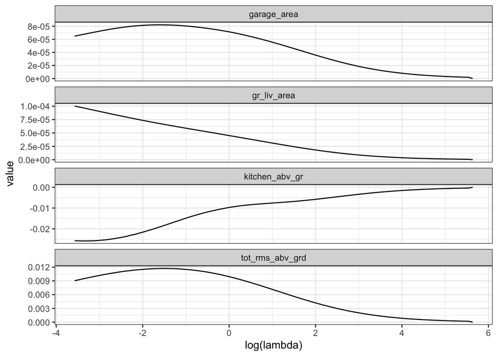

```r
selected_variables <- c("gr_liv_area", "tot_rms_abv_grd", "garage_area",  "kitchen_abv_gr")
ggplot(
  data = ridge_coeffs %>% filter(variable %in% selected_variables),
  aes(x = log(lambda), y = value)) +
    geom_line() +
  facet_wrap(~ variable, scales = "free_y", ncol = 1)
```

We can use cross-validation to determine the optimal penalty term weight. Two lambda values marked on the plot: one with the minimal CV RMSE, the other is the simplest model (highest lambda) which contains the optimal lambda’s error within one standard deviation. That is, it gives the simplest model that is still “good enough”.

```r
set.seed(1234)
ridge_model_cv <- cv.glmnet(
  x = x_train, y = data_train[["log_sale_price"]],
  family = "gaussian",
  alpha = 0,
  nfolds = 10
)

best_lambda <- ridge_model_cv$lambda.min
message(paste0("The optimally chosen penalty parameter: ", best_lambda))
```

```
## The optimally chosen penalty parameter: 0.180129135344916
```

```r
highest_good_enough_lambda <- ridge_model_cv$lambda.1se
message(paste0("The highest good enough penalty parameter: ", highest_good_enough_lambda))
```

```
## The highest good enough penalty parameter: 0.875896216853839
```

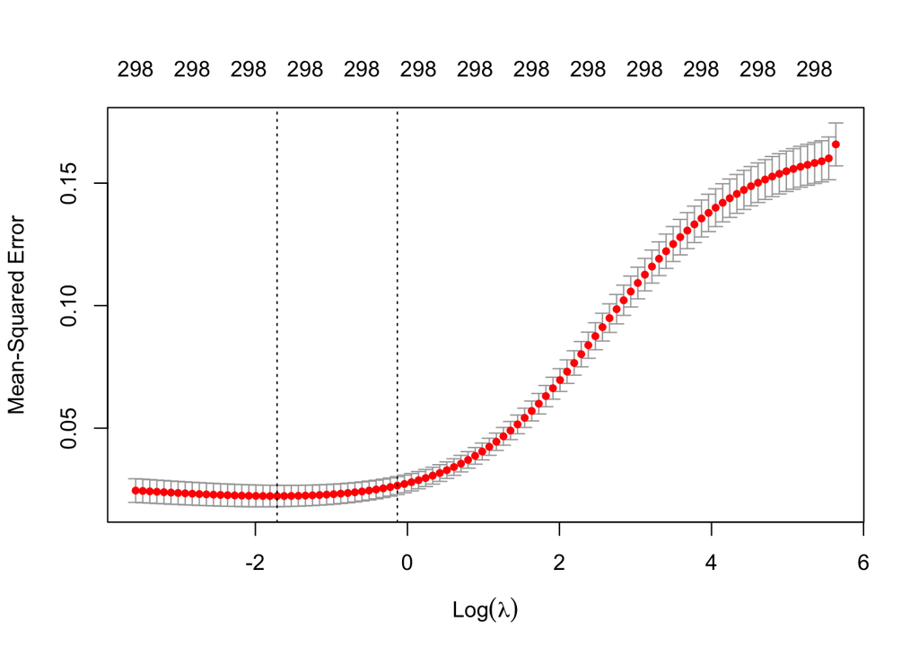

```r
plot(ridge_model_cv)
```

We can also use `caret` to estimate ridge models. This lets us compare it later to any other model estimated with caret, using, for example, cross-validation with exactly the same folds.

```r
# ridge model
ridge_tune_grid <- expand.grid(
  "alpha" = c(0),
  "lambda" = seq(0.05, 0.5, by = 0.025)
)

set.seed(857)
ridge_fit <- train(
  log_sale_price ~ . -sale_price,
  data = data_train,
  method = "glmnet",
  preProcess = c("center", "scale"),
  tuneGrid = ridge_tune_grid,
  trControl = fit_control
)
```

```r
ridge_fit
```

```
## glmnet
##
## 2053 samples
##   81 predictor
##
## Pre-processing: centered (308), scaled (308)
## Resampling: Cross-Validated (10 fold)
## Summary of sample sizes: 1847, 1849, 1849, 1847, 1848, 1847, ...
## Resampling results across tuning parameters:
##
##   lambda  RMSE       Rsquared   MAE
##   0.050   0.1464742  0.8707003  0.08654948
##   0.075   0.1446715  0.8732402  0.08641530
##   0.100   0.1436810  0.8746908  0.08668066
##   0.125   0.1431577  0.8755367  0.08716370
##   0.150   0.1429352  0.8760033  0.08772921
##   0.175   0.1429234  0.8762089  0.08830684
##   0.200   0.1430586  0.8762391  0.08891297
##   0.225   0.1433025  0.8761429  0.08951049
##   0.250   0.1436295  0.8759524  0.09012103
##   0.275   0.1440211  0.8756904  0.09074102
##   0.300   0.1444622  0.8753753  0.09135751
##   0.325   0.1449408  0.8750214  0.09196578
##   0.350   0.1454497  0.8746372  0.09257827
##   0.375   0.1459867  0.8742271  0.09318557
##   0.400   0.1465406  0.8737999  0.09377238
##   0.425   0.1471172  0.8733518  0.09436542
##   0.450   0.1477083  0.8728943  0.09495540
##   0.475   0.1483059  0.8724337  0.09554946
##   0.500   0.1489224  0.8719555  0.09615197
##
## Tuning parameter 'alpha' was held constant at a value of 0
## RMSE was used to select the optimal model using the smallest value.
## The final values used for the model were alpha = 0 and lambda = 0.175.
```

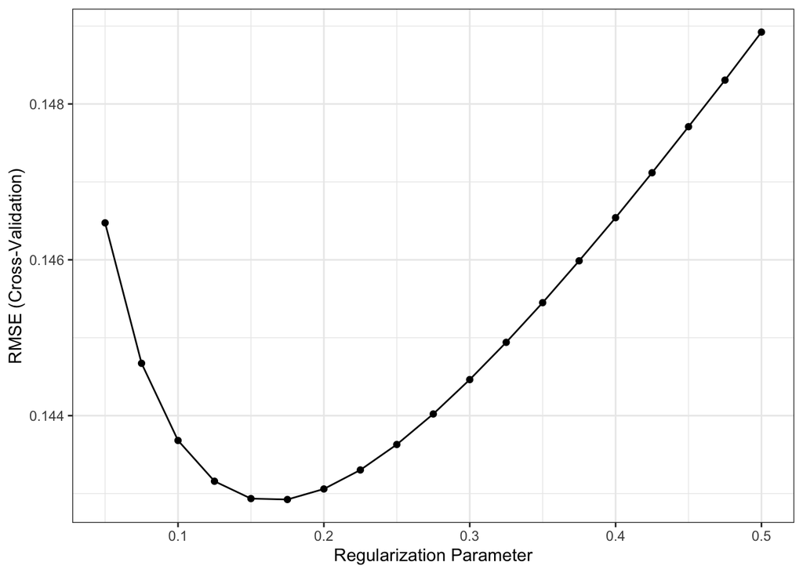

```r
ggplot(ridge_fit)
```

## Another variant: LASSO regression

While Ridge applies a constraint on the sum of squares of coefficients, LASSO does the same for the sum of the **absolute values** of coefficients.

This seemingly small difference has important sconsequences: some coefficients are set exactly to zero, others are only shrunk towards zero.

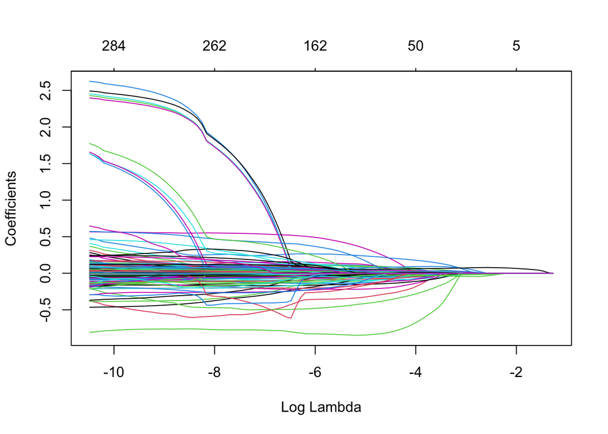

```r
set.seed(1234)
lasso_model <- glmnet(
  x = x_train, y = data_train[["log_sale_price"]],
  family = "gaussian",
  alpha = 1  # the lasso model
)

plot(lasso_model, xvar = "lambda")
```

Again, let’s look at individual coefficients. We can see that some are set exactly to zero for higher values of the penalty term. This is in contrast to what we saw with the Ridge model.

```r
lasso_coeffs <- get_glmnet_coeff_sequence(lasso_model)
```

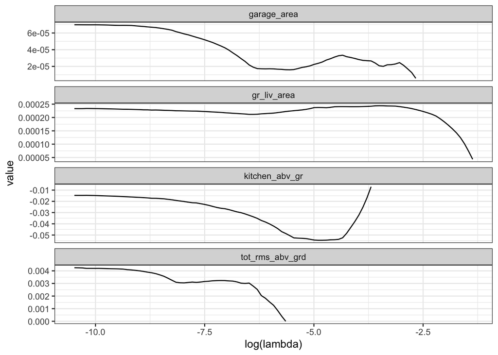

```r
selected_variables <- c("gr_liv_area", "tot_rms_abv_grd", "garage_area", "kitchen_abv_gr")
ggplot(
  data = lasso_coeffs %>% filter(variable %in% selected_variables),
  aes(x = log(lambda), y = value)) +
    geom_line() +
  facet_wrap(~ variable, scales = "free_y", ncol = 1)
```

Again, we can apply cross-validation to determine the optimal value for the penalty term.

```r
set.seed(1234)
lasso_model_cv <- cv.glmnet(
  x = x_train, y = data_train[["log_sale_price"]],
  family = "gaussian",
  alpha = 1,
  nfolds = 10
)

best_lambda <- lasso_model_cv$lambda.min
message(paste0("The optimally chosen penalty parameter: ", best_lambda))
```

```
## The optimally chosen penalty parameter: 0.00388076456762921
```

```r
highest_good_enough_lambda <- lasso_model_cv$lambda.1se
message(paste0("The highest good enough penalty parameter: ", highest_good_enough_lambda))
```

```
## The highest good enough penalty parameter: 0.0227297188251623
```

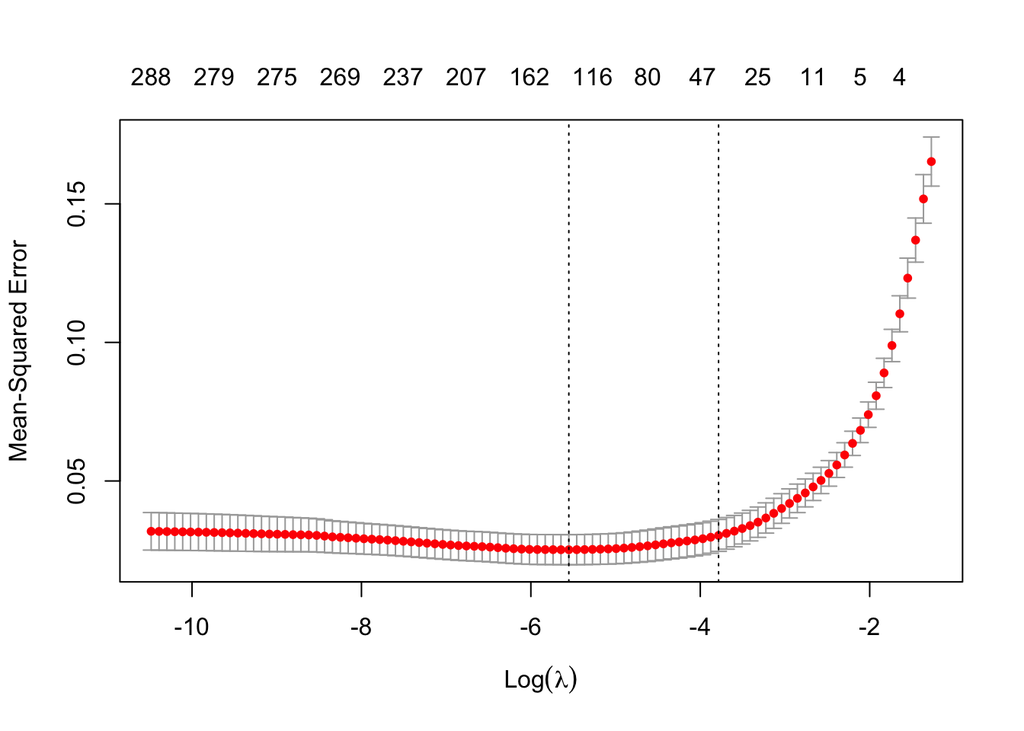

```r
plot(lasso_model_cv)
```

Fitting LASSO models with `caret` is similar to that of Ridge.

```r
tenpowers <- 10^seq(-1, -5, by = -1)

lasso_tune_grid <- expand.grid(
  "alpha" = c(1),
  "lambda" = c(tenpowers, tenpowers / 2)
)

set.seed(857)
lasso_fit <- train(
  log_sale_price ~ . -sale_price,
  data = data_train,
  method = "glmnet",
  preProcess = c("center", "scale"),
  tuneGrid = lasso_tune_grid,
  trControl = fit_control
)
```

```r
lasso_fit
```

```
## glmnet
##
## 2053 samples
##   81 predictor
##
## Pre-processing: centered (308), scaled (308)
## Resampling: Cross-Validated (10 fold)
## Summary of sample sizes: 1847, 1849, 1849, 1847, 1848, 1847, ...
## Resampling results across tuning parameters:
##
##   lambda  RMSE       Rsquared   MAE
##   5e-06   0.1724948  0.8316208  0.08760109
##   1e-05   0.1724948  0.8316208  0.08760109
##   5e-05   0.1719195  0.8325130  0.08753221
##   1e-04   0.1701065  0.8353641  0.08724015
##   5e-04   0.1608812  0.8493622  0.08610976
##   1e-03   0.1549066  0.8580135  0.08566133
##   5e-03   0.1481077  0.8664453  0.08711685
##   1e-02   0.1534121  0.8580125  0.09303712
##   5e-02   0.1970917  0.8002051  0.13039984
##   1e-01   0.2394941  0.7692260  0.16621033
##
## Tuning parameter 'alpha' was held constant at a value of 1
## RMSE was used to select the optimal model using the smallest value.
## The final values used for the model were alpha = 1 and lambda = 0.005.
```

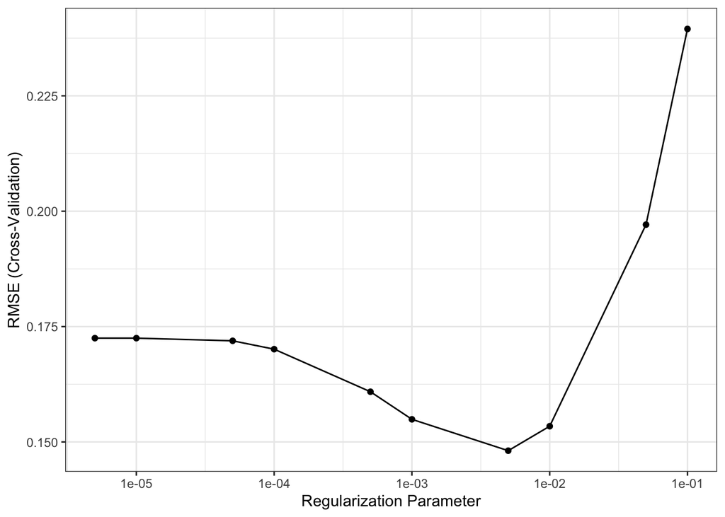

```r
ggplot(lasso_fit) + scale_x_log10()
```

### Variable selection - why is it happening?

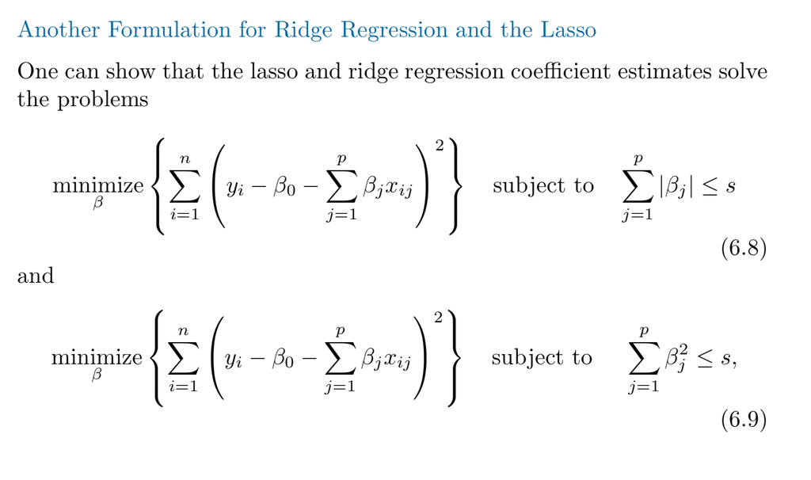

The constraints are different: LASSO’s has corners, Ridge’s is smooth. Corners mean some coefficients being exactly zero.

Source: Introduction to Statistical Learning

## Combine Ridge and LASSO: Elastic net

We can combine both types of penalties. LASSO is attractive since it performs principled variable selection. However, when having correlated features, typically only one of them - quite arbitrarily - is kept in the model. Ridge simultaneously shrinks coefficients of these towards zero. If we apply penalties of both the absolute values and the squares of the coefficients, both virtues are retained. This method is called Elastic net.

```r
enet_tune_grid <- expand.grid(
  "alpha" = seq(0, 1, by = 0.1),
  "lambda" = union(lasso_tune_grid[["lambda"]], ridge_tune_grid[["lambda"]])
)

set.seed(857)
enet_fit <- train(
  log_sale_price ~ . -sale_price,
  data = data_train,
  method = "glmnet",
  preProcess = c("center", "scale"),
  tuneGrid = enet_tune_grid,
  trControl = fit_control
)
```

```r
enet_fit
```

```
## glmnet
##
## 2053 samples
##   81 predictor
##
## Pre-processing: centered (308), scaled (308)
## Resampling: Cross-Validated (10 fold)
## Summary of sample sizes: 1847, 1849, 1849, 1847, 1848, 1847, ...
## Resampling results across tuning parameters:
##
##   alpha  lambda    RMSE       Rsquared   MAE
##   0.0    0.000005  0.1494346  0.8665309  0.08716389
##   0.0    0.000010  0.1494346  0.8665309  0.08716389
##   0.0    0.000050  0.1494346  0.8665309  0.08716389
##   0.0    0.000100  0.1494346  0.8665309  0.08716389
##   0.0    0.000500  0.1494346  0.8665309  0.08716389
##   0.0    0.001000  0.1494346  0.8665309  0.08716389
##   0.0    0.005000  0.1494346  0.8665309  0.08716389
##   0.0    0.010000  0.1494346  0.8665309  0.08716389
##   0.0    0.050000  0.1464742  0.8707003  0.08654948
##   0.0    0.075000  0.1446715  0.8732402  0.08641530
##   0.0    0.100000  0.1436810  0.8746908  0.08668066
##   0.0    0.125000  0.1431577  0.8755367  0.08716370
##   0.0    0.150000  0.1429352  0.8760033  0.08772921
##   0.0    0.175000  0.1429234  0.8762089  0.08830684
##   0.0    0.200000  0.1430586  0.8762391  0.08891297
##   0.0    0.225000  0.1433025  0.8761429  0.08951049
##   0.0    0.250000  0.1436295  0.8759524  0.09012103
##   0.0    0.275000  0.1440211  0.8756904  0.09074102
##   0.0    0.300000  0.1444622  0.8753753  0.09135751
##   0.0    0.325000  0.1449408  0.8750214  0.09196578
##   0.0    0.350000  0.1454497  0.8746372  0.09257827
##   0.0    0.375000  0.1459867  0.8742271  0.09318557
##   0.0    0.400000  0.1465406  0.8737999  0.09377238
##   0.0    0.425000  0.1471172  0.8733518  0.09436542
##   0.0    0.450000  0.1477083  0.8728943  0.09495540
##   0.0    0.475000  0.1483059  0.8724337  0.09554946
##   0.0    0.500000  0.1489224  0.8719555  0.09615197
##   0.1    0.000005  0.1670353  0.8403192  0.08758031
##   0.1    0.000010  0.1670353  0.8403192  0.08758031
```

[output cut: 256 more lines]

```
##   1.0    0.225000  0.3613613  0.6292399  0.27442996
##   1.0    0.250000  0.3835125  0.5855161  0.29335653
##   1.0    0.275000  0.4029942  0.5599177  0.30958250
##   1.0    0.300000  0.4067417        NaN  0.31268761
##   1.0    0.325000  0.4067417        NaN  0.31268761
##   1.0    0.350000  0.4067417        NaN  0.31268761
##   1.0    0.375000  0.4067417        NaN  0.31268761
##   1.0    0.400000  0.4067417        NaN  0.31268761
##   1.0    0.425000  0.4067417        NaN  0.31268761
##   1.0    0.450000  0.4067417        NaN  0.31268761
##   1.0    0.475000  0.4067417        NaN  0.31268761
##   1.0    0.500000  0.4067417        NaN  0.31268761
##
## RMSE was used to select the optimal model using the smallest value.
## The final values used for the model were alpha = 0 and lambda = 0.175.
```

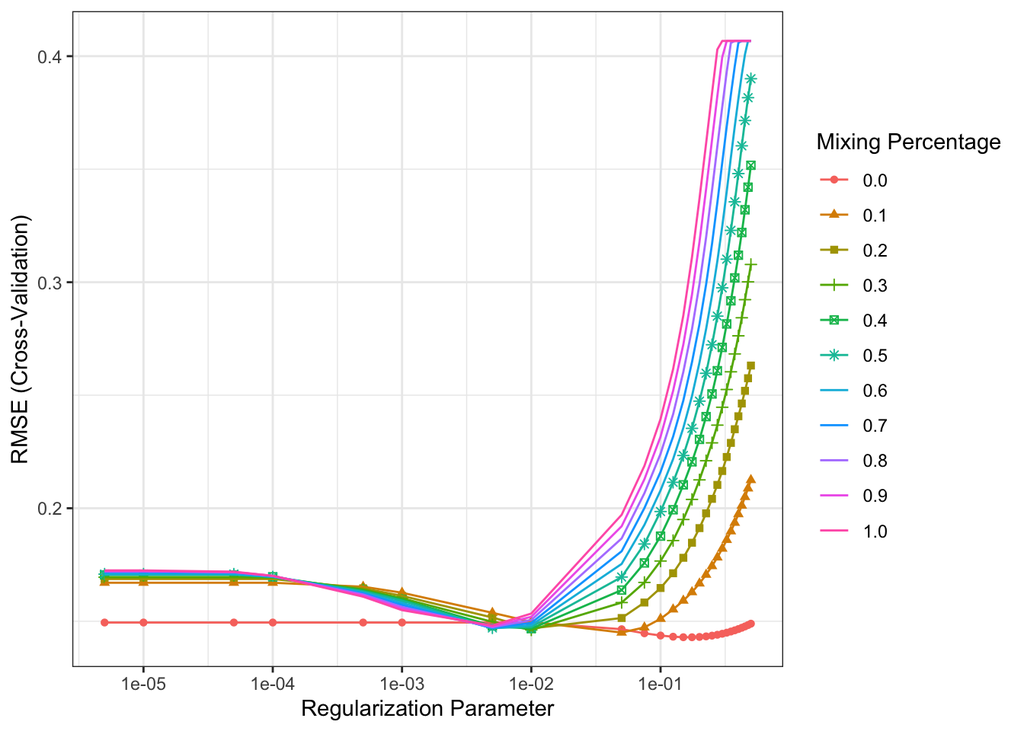

```r
ggplot(enet_fit) + scale_x_log10()
```

## Evaluate all models

For completeness, estimate the non-regularized linear model as well.

```r
set.seed(857)
linear_fit <- train(
  log_sale_price ~ . -sale_price,
  data = data_train,
  method = "lm",
  preProcess = c("center", "scale"),
  trControl = fit_control
)
```

```r
resample_profile <- resamples(
  list("linear" = linear_fit,
       "ridge" = ridge_fit,
       "lasso" = lasso_fit,
       "elastic net" = enet_fit
  )
)

summary(resample_profile)
```

```
##
## Call:
## summary.resamples(object = resample_profile)
##
## Models: linear, ridge, lasso, elastic net
## Number of resamples: 10
##
## MAE
##                   Min.    1st Qu.     Median       Mean    3rd Qu.      Max.
## linear      0.07777197 0.07940461 0.09265443 0.08873995 0.09527491 0.0987329
## ridge       0.07367948 0.08026915 0.08802844 0.08830684 0.09413163 0.1061065
## lasso       0.07086193 0.08087593 0.08594562 0.08711685 0.09203586 0.1047683
## elastic net 0.07367948 0.08026915 0.08802844 0.08830684 0.09413163 0.1061065
##             NA's
## linear         0
## ridge          0
## lasso          0
## elastic net    0
##
## RMSE
##                   Min.   1st Qu.    Median      Mean   3rd Qu.      Max. NA's
## linear      0.11238141 0.1364270 0.1721632 0.1771764 0.2204885 0.2404686    0
## ridge       0.09860469 0.1175353 0.1319301 0.1429234 0.1472833 0.2196785    0
## lasso       0.09536545 0.1233744 0.1333620 0.1481077 0.1520182 0.2372004    0
## elastic net 0.09860469 0.1175353 0.1319301 0.1429234 0.1472833 0.2196785    0
##
## Rsquared
##                  Min.   1st Qu.    Median      Mean   3rd Qu.      Max. NA's
## linear      0.7147800 0.7634893 0.8286702 0.8249801 0.8875117 0.9207508    0
## ridge       0.7488259 0.8582377 0.8939727 0.8762089 0.9185868 0.9253607    0
## lasso       0.7119918 0.8498486 0.8874229 0.8664453 0.9117261 0.9298672    0
## elastic net 0.7488259 0.8582377 0.8939727 0.8762089 0.9185868 0.9253607    0
```

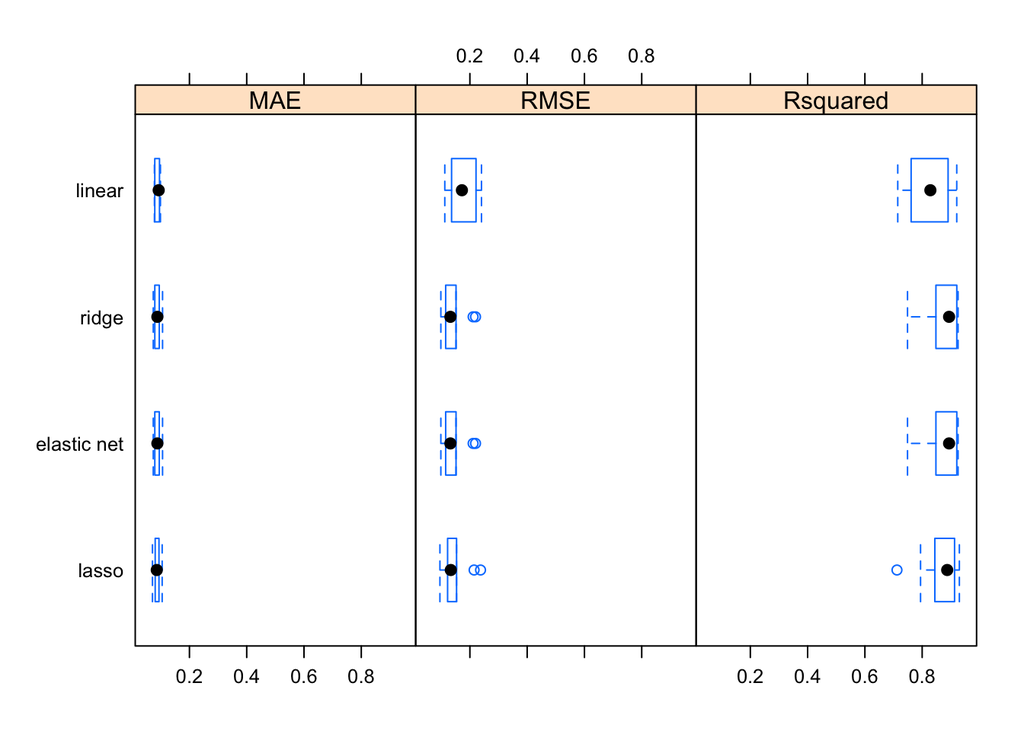

```r
bwplot(resample_profile)
```

Are differences between models large in a statistical sense? Not really. What we can certainly see is that the plain linear model’s variance is much larger than that of the penalized ones.

```r
model_differences <- diff(resample_profile)
```

```r
summary(model_differences)
```

```
##
## Call:
## summary.diff.resamples(object = model_differences)
##
## p-value adjustment: bonferroni
## Upper diagonal: estimates of the difference
## Lower diagonal: p-value for H0: difference = 0
##
## MAE
##             linear ridge      lasso      elastic net
## linear              0.0004331  0.0016231  0.0004331
## ridge       1                  0.0011900  0.0000000
## lasso       1      1                     -0.0011900
## elastic net 1      NA         1
##
## RMSE
##             linear  ridge     lasso     elastic net
## linear               0.034253  0.029069  0.034253
## ridge       0.09586           -0.005184  0.000000
## lasso       0.24831 0.49739              0.005184
## elastic net 0.09586 NA        0.49739
##
## Rsquared
##             linear ridge     lasso     elastic net
## linear             -0.051229 -0.041465 -0.051229
## ridge       0.1170            0.009764  0.000000
## lasso       0.3528 0.3374              -0.009764
## elastic net 0.1170 NA        0.3374
```

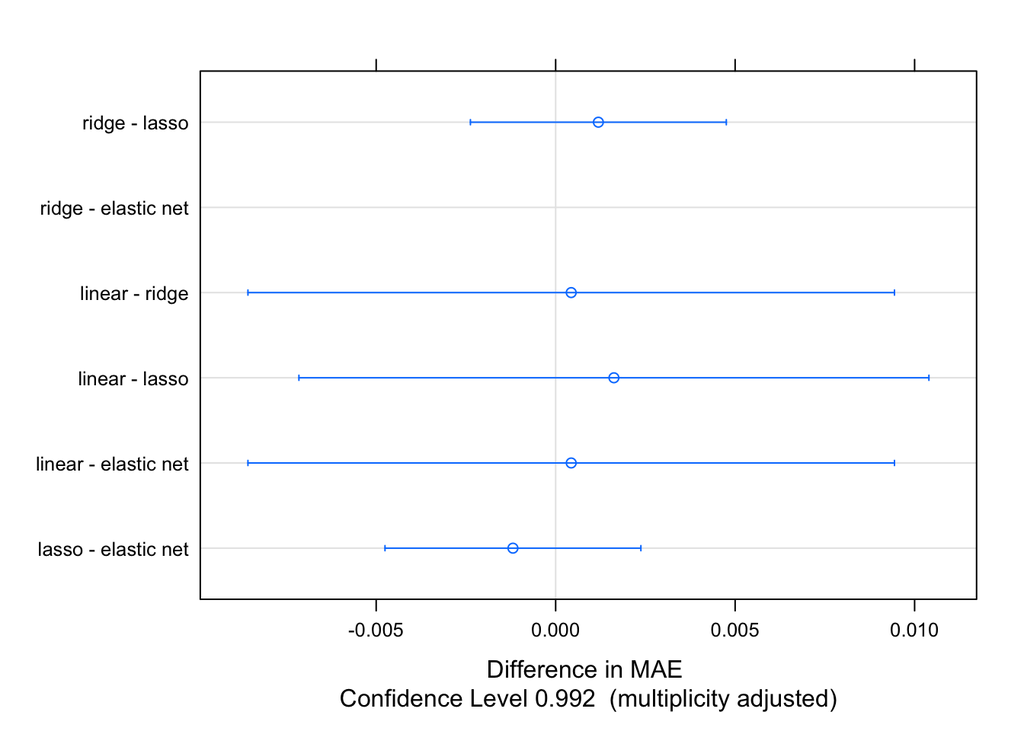

```r
dotplot(model_differences)
```

### Evaluate the chosen model on holdout set

```r
RMSE(predict(enet_fit, newdata = data_test), data_test[["log_sale_price"]])
```

```
## [1] 0.1268464
```

## Recommended readings

- [Tutorial of the Air Force Institute of Technology](https://afit-r.github.io/regularized_regression) - based on which this lab was put together
- [Elements of Statistical Learning](https://web.stanford.edu/~hastie/ElemStatLearn/) - the standard reference book of machine learning (freely available)
- [Introduction to Statistical Learning](http://www-bcf.usc.edu/~gareth/ISL/) - a more accessible treatment of the same material from the same authors (with R codes)
- [Applied Predictive Modelling](http://appliedpredictivemodeling.com/) - a thorough and practical guide to predictive modelling from the author of the `caret` package (with R code)